# The Effects of Generative AI on Design Fixation and Divergent Thinking | Supplementary Material

Anonymous

2023-09-21

# 1 Introduction

This code contains the process and the models that were used to analyze outcomes related to design fixation (see section 2.1), fluency (see section 2.2), variety (see section 2.3) and originality (see section 2.4) of design ideas with Bayesian statistics.In section 2.5 we report the process we followed in the correlation analysis of design fixation scores of AI generated images and the design fixation scores of participants.

We make use of `tidyverse` (Wickham et al. 2019), which allows for cleaner, easier to read code. One feature from `tidyverse` is the pipe (`%>%`) which allows which allows the user to string together multiple commands, taking the output of one command as the input to the next. For our analysis we used the `brms` package (Bürkner 2017) to fit our models. This package facilitates the implementation of Bayesian multilevel models in R, leveraging the Stan probabilistic programming language (Carpenter et al. 2017). To ensure the reliability of our Bayesian Markov Chain Monte Carlo (MCMC) sampling process, we assessed convergence and stability through two metrics: R-hat, which should ideally be less than 1.01 (Vehtari et al. 2021), and the Effective Sample Size (ESS), which should ideally exceed 1000 (Bürkner 2017).

For the correlation analysis we used Spearman’s rank correlation (a non-parametric test) as the data did not satisfy normality assumptions. To perform Spearman’s rank correlation in R we used `cor.test` function (see section 2.5).

In section 2.6 we report the findings of NASA-TLX.

# 2 Measures

## 2.1 Design fixation

This section contains outcomes related to design fixation.

### Data

```r
#Set working directory
setwd("~/Desktop/data") #Setup the working directory (where the data is)

#read data file
data_dfs <- read.csv("data_dfs.csv")
```

### Modelling

```r
summary(mDFSBinom, prob = .89)
```

```
##  Family: binomial
##   Links: mu = probit
## Formula: dfs_count | trials(14) ~ 1 + Condition + (1 | id) + (1 | img_id)
##    Data: dat2 (Number of observations: 554)
##   Draws: 4 chains, each with iter = 4000; warmup = 2000; thin = 1;
##          total post-warmup draws = 8000
##
## Group-Level Effects:
## ~id (Number of levels: 60)
##               Estimate Est.Error l-89% CI u-89% CI Rhat Bulk_ESS Tail_ESS
## sd(Intercept)     0.35      0.05     0.28     0.43 1.00     3490     5060
##
## ~img_id (Number of levels: 277)
##               Estimate Est.Error l-89% CI u-89% CI Rhat Bulk_ESS Tail_ESS
## sd(Intercept)     0.37      0.03     0.32     0.41 1.00     3205     5450
##
## Population-Level Effects:
##                     Estimate Est.Error l-89% CI u-89% CI Rhat Bulk_ESS Tail_ESS
## Intercept              -0.71      0.10    -0.86    -0.56 1.00     4499     5105
## ConditionGISsupport     0.27      0.14     0.05     0.48 1.00     4423     5378
## ConditionAISupport      0.32      0.13     0.11     0.54 1.00     4590     5240
##
## Draws were sampled using sample(hmc). For each parameter, Bulk_ESS
## and Tail_ESS are effective sample size measures, and Rhat is the potential
## scale reduction factor on split chains (at convergence, Rhat = 1).
```

### Hypothesis testing

```r
hypothesis(mDFSBinom,
           c("ConditionAISupport > 0",
             "ConditionGISsupport > 0"))
```

```
## Hypothesis Tests for class b:
##                 Hypothesis Estimate Est.Error CI.Lower CI.Upper Evid.Ratio
## 1 (ConditionAISupport) > 0     0.32      0.13     0.11     0.55     124.00
## 2 (ConditionGISsupp... > 0     0.27      0.14     0.05     0.49      42.48
##   Post.Prob Star
## 1      0.99    *
## 2      0.98    *
## ---
## 'CI': 90%-CI for one-sided and 95%-CI for two-sided hypotheses.
## '*': For one-sided hypotheses, the posterior probability exceeds 95%;
## for two-sided hypotheses, the value tested against lies outside the 95%-CI.
## Posterior probabilities of point hypotheses assume equal prior probabilities.
```

```r
             # "ConditionAISupport:ai_image_familiarityYes < 0"))
```

### Plots

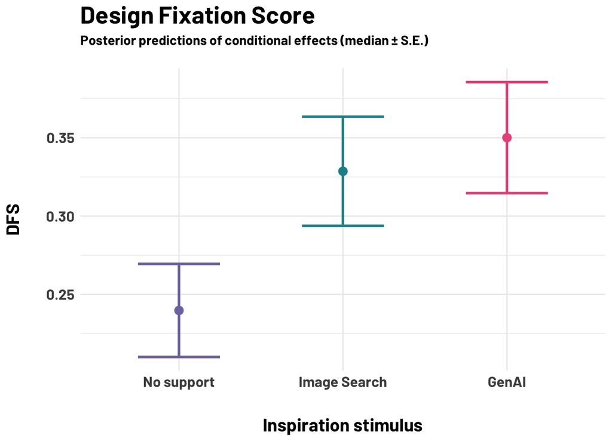

```r
ce <- conditional_effects(mDFSBinom, ask=FALSE, plot=FALSE, robust=TRUE)[[1]]
# Normalising
ce$estimate__ <- ce$estimate__/14
ce$lower__ <- ce$lower__/14
ce$upper__ <- ce$upper__/14
ce$se__ <- ce$se__/14

# Define custom colors
colors <- c("#8077B0","#1C9099","#E8598A")

ggplot(ce, aes(x = effect1__, y = estimate__, col = effect1__))+
  geom_point(position = position_dodge(.6),size=3)+
  geom_errorbar(aes(ymin = estimate__-se__, ymax = estimate__+se__, col = effect1__),
                width = .5, position = position_dodge(.6),size=1)+
  scale_color_manual(values = colors) +
  theme_minimal() +
  theme(
    plot.title = element_text(face = "bold", size = 20),
    legend.background = element_rect(
      fill = "white",
      linewidth = 4,
      colour = "white"
    ),
    legend.position="none",
    text = element_text(family = "Barlow", face = "bold"),
    axis.title.x = element_text(size = 15, vjust = -.5, ),
      axis.title.y = element_text(size = 15),
    axis.text.x = element_text(size = 12),
    axis.text.y = element_text(size = 12)
  )+
  scale_color_manual(values = colors) +
  scale_x_discrete(labels=c('No support', 'Image Search', 'GenAI')) +
  labs(title="Design Fixation Score",
          subtitle = "Posterior predictions of conditional effects (median ± S.E.)\n")+
    xlab("\nInspiration stimulus")+
    ylab("DFS\n")+
    labs(col="GenAI experience")+
  guides(col = guide_legend(nrow = 1, byrow = TRUE))
```

## 2.2 Fluency

This section contains outcomes related to Fluency.

### Data

```r
#Set working directory
setwd("~/Desktop/data") #Setup the working directory (where the data is)

#read data file
data_fluency <- read.csv("data_demographics_updated.csv")
```

### Modelling

```r
summary(mFluency, prob = .89)
```

```
##  Family: negbinomial
##   Links: mu = log; shape = log
## Formula: fluency_corrected ~ 1 + Condition
##          shape ~ 1 + Condition
##    Data: data_fluency (Number of observations: 60)
##   Draws: 4 chains, each with iter = 3000; warmup = 1500; thin = 1;
##          total post-warmup draws = 6000
##
## Population-Level Effects:
##                           Estimate Est.Error l-89% CI u-89% CI Rhat Bulk_ESS
## Intercept                     1.50      0.19     1.20     1.81 1.00     4846
## shape_Intercept               0.77      0.46     0.07     1.51 1.00     6286
## ConditionGISsupport          -0.49      0.25    -0.88    -0.11 1.00     4985
## ConditionAISupport           -0.21      0.30    -0.69     0.27 1.00     4156
## shape_ConditionGISsupport     1.66      1.14     0.05     3.62 1.00     3406
## shape_ConditionAISupport     -0.40      0.65    -1.45     0.64 1.00     5798
##                           Tail_ESS
## Intercept                     4137
## shape_Intercept               4540
## ConditionGISsupport           4296
## ConditionAISupport            3958
## shape_ConditionGISsupport     3203
## shape_ConditionAISupport      4174
##
## Draws were sampled using sample(hmc). For each parameter, Bulk_ESS
## and Tail_ESS are effective sample size measures, and Rhat is the potential
## scale reduction factor on split chains (at convergence, Rhat = 1).
```

```r
summary(mFluencyTotal, prob = .89)
```

```
##  Family: negbinomial
##   Links: mu = log; shape = log
## Formula: fluency_corrected ~ 1 + Condition + offset(log(ToT))
##          shape ~ 1 + Condition
##    Data: data_fluency (Number of observations: 60)
##   Draws: 4 chains, each with iter = 3000; warmup = 1500; thin = 1;
##          total post-warmup draws = 6000
##
## Population-Level Effects:
##                           Estimate Est.Error l-89% CI u-89% CI Rhat Bulk_ESS
## Intercept                    -1.48      0.19    -1.79    -1.17 1.00     4674
## shape_Intercept               0.75      0.45     0.04     1.47 1.00     6568
## ConditionGISsupport          -0.22      0.25    -0.63     0.17 1.00     4737
## ConditionAISupport            0.10      0.31    -0.39     0.58 1.00     4653
## shape_ConditionGISsupport     1.58      1.15    -0.01     3.61 1.00     3572
## shape_ConditionAISupport     -0.51      0.61    -1.49     0.47 1.00     6458
##                           Tail_ESS
## Intercept                     3621
## shape_Intercept               4792
## ConditionGISsupport           4175
## ConditionAISupport            4368
## shape_ConditionGISsupport     2880
## shape_ConditionAISupport      4864
##
## Draws were sampled using sample(hmc). For each parameter, Bulk_ESS
## and Tail_ESS are effective sample size measures, and Rhat is the potential
## scale reduction factor on split chains (at convergence, Rhat = 1).
```

### Hypothesis testing

```r
hypothesis(mFluency,
           c("ConditionAISupport < 0",
             "ConditionGISsupport < 0"),)
```

```
## Hypothesis Tests for class b:
##                 Hypothesis Estimate Est.Error CI.Lower CI.Upper Evid.Ratio
## 1 (ConditionAISupport) < 0    -0.21      0.30     -0.7     0.28       3.20
## 2 (ConditionGISsupp... < 0    -0.49      0.25     -0.9    -0.10      46.62
##   Post.Prob Star
## 1      0.76
## 2      0.98    *
## ---
## 'CI': 90%-CI for one-sided and 95%-CI for two-sided hypotheses.
## '*': For one-sided hypotheses, the posterior probability exceeds 95%;
## for two-sided hypotheses, the value tested against lies outside the 95%-CI.
## Posterior probabilities of point hypotheses assume equal prior probabilities.
```

```r
hypothesis(mFluencyTotal,
           c("ConditionAISupport < 0",
             "ConditionGISsupport < 0"),)
```

```
## Hypothesis Tests for class b:
##                 Hypothesis Estimate Est.Error CI.Lower CI.Upper Evid.Ratio
## 1 (ConditionAISupport) < 0     0.10      0.31    -0.41     0.60       0.61
## 2 (ConditionGISsupp... < 0    -0.22      0.25    -0.64     0.19       4.20
##   Post.Prob Star
## 1      0.38
## 2      0.81
## ---
## 'CI': 90%-CI for one-sided and 95%-CI for two-sided hypotheses.
## '*': For one-sided hypotheses, the posterior probability exceeds 95%;
## for two-sided hypotheses, the value tested against lies outside the 95%-CI.
## Posterior probabilities of point hypotheses assume equal prior probabilities.
```

### Plots

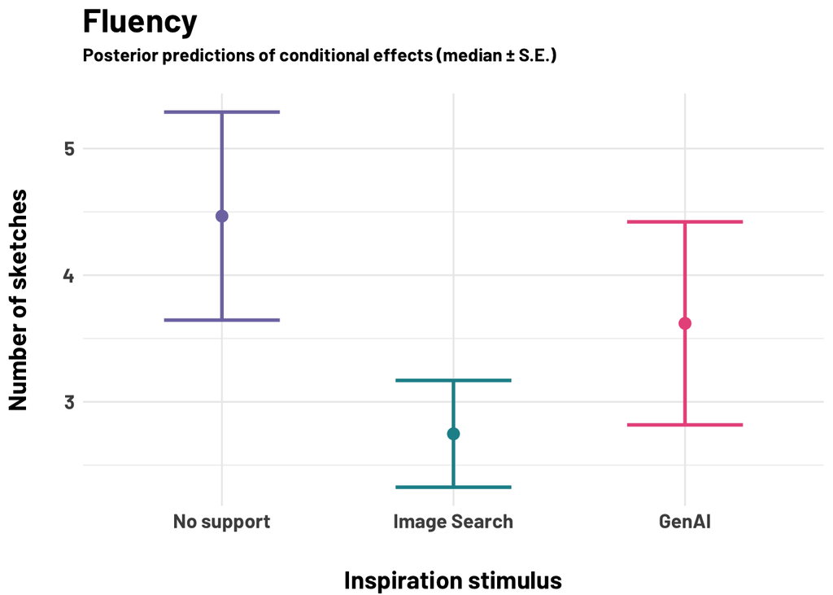

```r
ce <- conditional_effects(mFluency, ask=FALSE, plot=FALSE, robust=TRUE)[[1]]

# Define custom colors
colors <- c("#8077B0","#1C9099","#E8598A")

ggplot(ce, aes(x = effect1__, y = estimate__, col = effect1__))+
  geom_point(position = position_dodge(.6),size=3)+
  geom_errorbar(aes(ymin = estimate__-se__, ymax = estimate__+se__, col = effect1__),
                width = .5, position = position_dodge(.6),size=1)+
  scale_color_manual(values = colors) +
  theme_minimal() +
  theme(
    plot.title = element_text(face = "bold", size = 20),
    legend.background = element_rect(
      fill = "white",
      linewidth = 4,
      colour = "white"
    ),
    legend.position="none",
    text = element_text(family = "Barlow", face = "bold"),
    axis.title.x = element_text(size = 15, vjust = -.5),
      axis.title.y = element_text(size = 15),
    axis.text.x = element_text(size = 12),
    axis.text.y = element_text(size = 12)
  )+
  scale_x_discrete(labels=c('No support', 'Image Search', 'GenAI'))+
     labs(title="Fluency",
          subtitle = "Posterior predictions of conditional effects (median ± S.E.)\n")+
  xlab("\nInspiration stimulus")+
  ylab("Number of sketches\n")+
  labs(col="GenAI experience")+
  guides(col = guide_legend(nrow = 1, byrow = TRUE))
```

## 2.3 Variety

This section contains outcomes related to Variety.

### Data

```r
#Set working directory
setwd("~/Desktop/data") #Setup the working directory (where the data is)
variety <- read.csv("data_variety.csv")
```

### Modelling

```r
summary(mVar, prob = .89)
```

```
##  Family: negbinomial
##   Links: mu = log; shape = identity
## Formula: variety_count ~ 1 + Condition + fluency
##    Data: data_variety (Number of observations: 60)
##   Draws: 4 chains, each with iter = 4000; warmup = 2000; thin = 1;
##          total post-warmup draws = 8000
##
## Population-Level Effects:
##                     Estimate Est.Error l-89% CI u-89% CI Rhat Bulk_ESS Tail_ESS
## Intercept              -0.00      0.23    -0.38     0.36 1.00     6029     4834
## ConditionGISsupport     0.02      0.25    -0.38     0.42 1.00     7325     5594
## ConditionAISupport     -0.15      0.24    -0.53     0.23 1.00     7072     5602
## fluency                 0.14      0.02     0.11     0.18 1.00     5680     4486
##
## Family Specific Parameters:
##       Estimate Est.Error l-89% CI u-89% CI Rhat Bulk_ESS Tail_ESS
## shape    32.87     43.60     5.09   105.97 1.00     6019     5738
##
## Draws were sampled using sample(hmc). For each parameter, Bulk_ESS
## and Tail_ESS are effective sample size measures, and Rhat is the potential
## scale reduction factor on split chains (at convergence, Rhat = 1).
```

```r
summary(mVarTotal, prob = .89)
```

```
##  Family: negbinomial
##   Links: mu = log; shape = identity
## Formula: variety_count ~ 1 + Condition
##    Data: data_variety (Number of observations: 60)
##   Draws: 4 chains, each with iter = 4000; warmup = 2000; thin = 1;
##          total post-warmup draws = 8000
##
## Population-Level Effects:
##                     Estimate Est.Error l-89% CI u-89% CI Rhat Bulk_ESS Tail_ESS
## Intercept               1.00      0.19     0.71     1.30 1.00     5838     5234
## ConditionGISsupport    -0.39      0.28    -0.84     0.06 1.00     6211     5257
## ConditionAISupport     -0.29      0.28    -0.74     0.17 1.00     6697     5373
##
## Family Specific Parameters:
##       Estimate Est.Error l-89% CI u-89% CI Rhat Bulk_ESS Tail_ESS
## shape     3.68      3.05     1.58     7.43 1.00     5699     3129
##
## Draws were sampled using sample(hmc). For each parameter, Bulk_ESS
## and Tail_ESS are effective sample size measures, and Rhat is the potential
## scale reduction factor on split chains (at convergence, Rhat = 1).
```

### Hypotheisi testing

```r
hypothesis(mVar,
           c("ConditionAISupport < 0",
             "ConditionGISsupport < 0"))
```

```
## Hypothesis Tests for class b:
##                 Hypothesis Estimate Est.Error CI.Lower CI.Upper Evid.Ratio
## 1 (ConditionAISupport) < 0    -0.15      0.24    -0.55     0.24       2.64
## 2 (ConditionGISsupp... < 0     0.02      0.25    -0.39     0.43       0.87
##   Post.Prob Star
## 1      0.73
## 2      0.46
## ---
## 'CI': 90%-CI for one-sided and 95%-CI for two-sided hypotheses.
## '*': For one-sided hypotheses, the posterior probability exceeds 95%;
## for two-sided hypotheses, the value tested against lies outside the 95%-CI.
## Posterior probabilities of point hypotheses assume equal prior probabilities.
```

```r
hypothesis(mVarTotal,
           c("ConditionAISupport < 0",
             "ConditionGISsupport < 0"))
```

```
## Hypothesis Tests for class b:
##                 Hypothesis Estimate Est.Error CI.Lower CI.Upper Evid.Ratio
## 1 (ConditionAISupport) < 0    -0.29      0.28    -0.76     0.18       5.71
## 2 (ConditionGISsupp... < 0    -0.39      0.28    -0.86     0.07      10.66
##   Post.Prob Star
## 1      0.85
## 2      0.91
## ---
## 'CI': 90%-CI for one-sided and 95%-CI for two-sided hypotheses.
## '*': For one-sided hypotheses, the posterior probability exceeds 95%;
## for two-sided hypotheses, the value tested against lies outside the 95%-CI.
## Posterior probabilities of point hypotheses assume equal prior probabilities.
```

### Plots

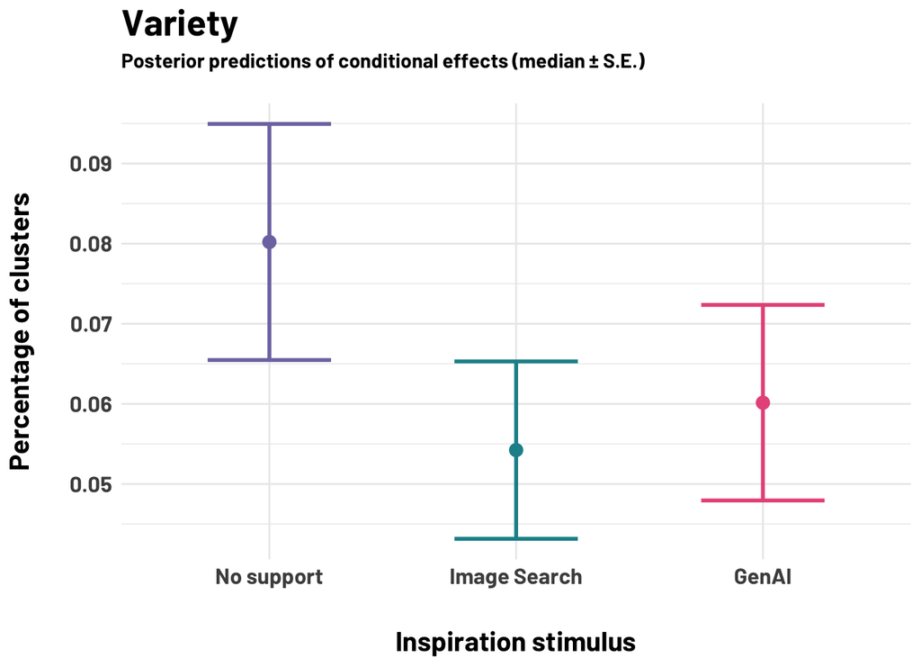

```r
ce <- conditional_effects(mVarTotal, ask=FALSE, plot=FALSE, robust=TRUE)[[1]]
ce$estimate__ <- ce$estimate__/34
ce$se__ <- ce$se__/34

# Define custom colors
colors <- c("#8077B0","#1C9099","#E8598A")



ggplot(ce, aes(x = effect1__,  y = estimate__, col = effect1__))+
  geom_point(position = position_dodge(.6),size=3)+
  geom_errorbar(aes(ymin = estimate__-se__, ymax = estimate__+se__, col = effect1__),
                width = .5, position = position_dodge(.6),size=1)+
  scale_color_manual(values = colors) +
  theme_minimal() +
  theme(
    plot.title = element_text(face = "bold", size = 20),
    legend.background = element_rect(
      fill = "white",
      linewidth = 4,
      colour = "white"
    ),
    legend.position="none",
    text = element_text(family = "Barlow", face = "bold"),
    axis.title.x = element_text(size = 15, vjust = -.5),
      axis.title.y = element_text(size = 15),
    axis.text.x = element_text(size = 12),
    axis.text.y = element_text(size = 12)
  )+
  scale_x_discrete(labels=c('No support', 'Image Search', 'GenAI'))+
     labs(title="Variety",
          subtitle = "Posterior predictions of conditional effects (median ± S.E.)\n")+
  xlab("\nInspiration stimulus")+
  ylab("Percentage of clusters\n")
```

## 2.4 Originality

This section contains outcomes related to Originality.

### Data

```r
#Set working directory
setwd("~/Desktop/data") #Setup the working directory (where the data is)

#read data file
data_originality <- read_csv("data_originality.csv")
```

### Modelling

```r
summary(mOrig, prob = .89)
```

```
##  Family: gaussian
##   Links: mu = identity; sigma = identity
## Formula: o_score ~ 1 + Condition + Variety + (1 | id)
##    Data: data_originality (Number of observations: 277)
##   Draws: 4 chains, each with iter = 4000; warmup = 2000; thin = 1;
##          total post-warmup draws = 8000
##
## Group-Level Effects:
## ~id (Number of levels: 60)
##               Estimate Est.Error l-89% CI u-89% CI Rhat Bulk_ESS Tail_ESS
## sd(Intercept)     0.02      0.01     0.00     0.03 1.00     1585     2400
##
## Population-Level Effects:
##                     Estimate Est.Error l-89% CI u-89% CI Rhat Bulk_ESS Tail_ESS
## Intercept               0.83      0.02     0.81     0.86 1.00     6133     5079
## ConditionGISsupport    -0.01      0.02    -0.03     0.02 1.00     6045     4856
## ConditionAISupport     -0.03      0.02    -0.05    -0.01 1.00     4956     4753
## Variety                 0.01      0.00     0.00     0.01 1.00     6929     4817
##
## Family Specific Parameters:
##       Estimate Est.Error l-89% CI u-89% CI Rhat Bulk_ESS Tail_ESS
## sigma     0.09      0.00     0.08     0.10 1.00     5511     5601
##
## Draws were sampled using sample(hmc). For each parameter, Bulk_ESS
## and Tail_ESS are effective sample size measures, and Rhat is the potential
## scale reduction factor on split chains (at convergence, Rhat = 1).
```

```r
summary(mOrigTotal, prob = .89)
```

```
##  Family: gaussian
##   Links: mu = identity; sigma = identity
## Formula: o_score ~ 1 + Condition + (1 | id)
##    Data: data_originality (Number of observations: 277)
##   Draws: 4 chains, each with iter = 4000; warmup = 2000; thin = 1;
##          total post-warmup draws = 8000
##
## Group-Level Effects:
## ~id (Number of levels: 60)
##               Estimate Est.Error l-89% CI u-89% CI Rhat Bulk_ESS Tail_ESS
## sd(Intercept)     0.02      0.01     0.01     0.04 1.00     1710     2080
##
## Population-Level Effects:
##                     Estimate Est.Error l-89% CI u-89% CI Rhat Bulk_ESS Tail_ESS
## Intercept               0.86      0.01     0.84     0.88 1.00     4742     4834
## ConditionGISsupport    -0.01      0.02    -0.04     0.01 1.00     6080     5526
## ConditionAISupport     -0.03      0.02    -0.06    -0.00 1.00     5690     4458
##
## Family Specific Parameters:
##       Estimate Est.Error l-89% CI u-89% CI Rhat Bulk_ESS Tail_ESS
## sigma     0.09      0.00     0.08     0.10 1.00     5975     5449
##
## Draws were sampled using sample(hmc). For each parameter, Bulk_ESS
## and Tail_ESS are effective sample size measures, and Rhat is the potential
## scale reduction factor on split chains (at convergence, Rhat = 1).
```

### Hypothesis testing

```r
hypothesis(mOrig,
           c("ConditionAISupport < 0",
             "ConditionGISsupport < 0"),)
```

```
## Hypothesis Tests for class b:
##                 Hypothesis Estimate Est.Error CI.Lower CI.Upper Evid.Ratio
## 1 (ConditionAISupport) < 0    -0.03      0.02    -0.05     0.00      34.87
## 2 (ConditionGISsupp... < 0    -0.01      0.02    -0.03     0.02       1.97
##   Post.Prob Star
## 1      0.97    *
## 2      0.66
## ---
## 'CI': 90%-CI for one-sided and 95%-CI for two-sided hypotheses.
## '*': For one-sided hypotheses, the posterior probability exceeds 95%;
## for two-sided hypotheses, the value tested against lies outside the 95%-CI.
## Posterior probabilities of point hypotheses assume equal prior probabilities.
```

```r
hypothesis(mOrigTotal,
           c("ConditionAISupport < 0",
             "ConditionGISsupport < 0"),)
```

```
## Hypothesis Tests for class b:
##                 Hypothesis Estimate Est.Error CI.Lower CI.Upper Evid.Ratio
## 1 (ConditionAISupport) < 0    -0.03      0.02    -0.06     0.00      34.09
## 2 (ConditionGISsupp... < 0    -0.01      0.02    -0.04     0.01       3.94
##   Post.Prob Star
## 1      0.97    *
## 2      0.80
## ---
## 'CI': 90%-CI for one-sided and 95%-CI for two-sided hypotheses.
## '*': For one-sided hypotheses, the posterior probability exceeds 95%;
## for two-sided hypotheses, the value tested against lies outside the 95%-CI.
## Posterior probabilities of point hypotheses assume equal prior probabilities.
```

### Plots

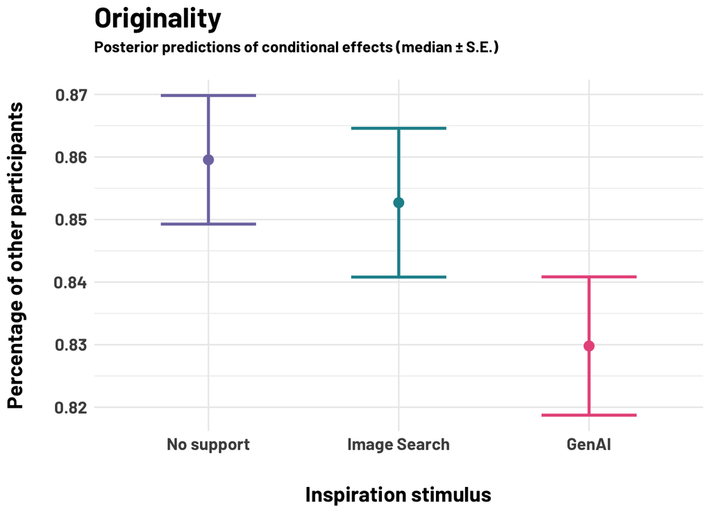

```r
ce <- conditional_effects(mOrig, ask=FALSE, plot=FALSE, robust=TRUE)[[1]]

# Define custom colors
colors <- c("#8077B0","#1C9099","#E8598A")


ggplot(ce, aes(x = effect1__,  y = estimate__, col = effect1__))+
  geom_point(position = position_dodge(.6),size=3)+
  geom_errorbar(aes(ymin = estimate__-se__, ymax = estimate__+se__, col= effect1__),
                width = .5, position = position_dodge(.6),size=1)+
  scale_color_manual(values = colors) +
  theme_minimal() +
  theme(
    plot.title = element_text(face = "bold", size = 20),
    legend.background = element_rect(
      fill = "white",
      linewidth = 4,
      colour = "white"
    ),
    legend.position="none",
    text = element_text(family = "Barlow", face = "bold"),
    axis.title.x = element_text(size = 15, vjust = -.5),
      axis.title.y = element_text(size = 15),
    axis.text.x = element_text(size = 12),
    axis.text.y = element_text(size = 12)
  )+
  scale_x_discrete(labels=c('No support', 'Image Search', 'GenAI'))+
     labs(title="Originality",
          subtitle = "Posterior predictions of conditional effects (median ± S.E.)\n")+
  xlab("\nInspiration stimulus")+
  ylab("Percentage of other participants\n")
```

## 2.5 Correlation Analysis

This section contains the correlation analysis of GenAI DFS and DFS of participant’s sketches.

### Data

```r
#Set working directory
setwd("~/Desktop/data") #Setup the working directory (where the data is)

#read data file
AI_Img_DFS_correlation <-read.csv("AI_Img_DFS_correlation.csv")
```

### Testing for normality

```r
shapiro.test(data$similarity)
```

```
##
##  Shapiro-Wilk normality test
##
## data:  data$similarity
## W = 0.90289, p-value = 1.296e-05
```

```r
shapiro.test(data$dfs)
```

```
##
##  Shapiro-Wilk normality test
##
## data:  data$dfs
## W = 0.97125, p-value = 0.0623
```

### Correlation Test

```r
corr2 <- cor.test(x=data$similarity, y=data$dfs, method = 'spearman',exact=FALSE)

corr2
```

```
##
##  Spearman's rank correlation rho
##
## data:  data$similarity and data$dfs
## S = 40141, p-value = 3.646e-08
## alternative hypothesis: true rho is not equal to 0
## sample estimates:
##       rho
## 0.5631203
```

### Plots

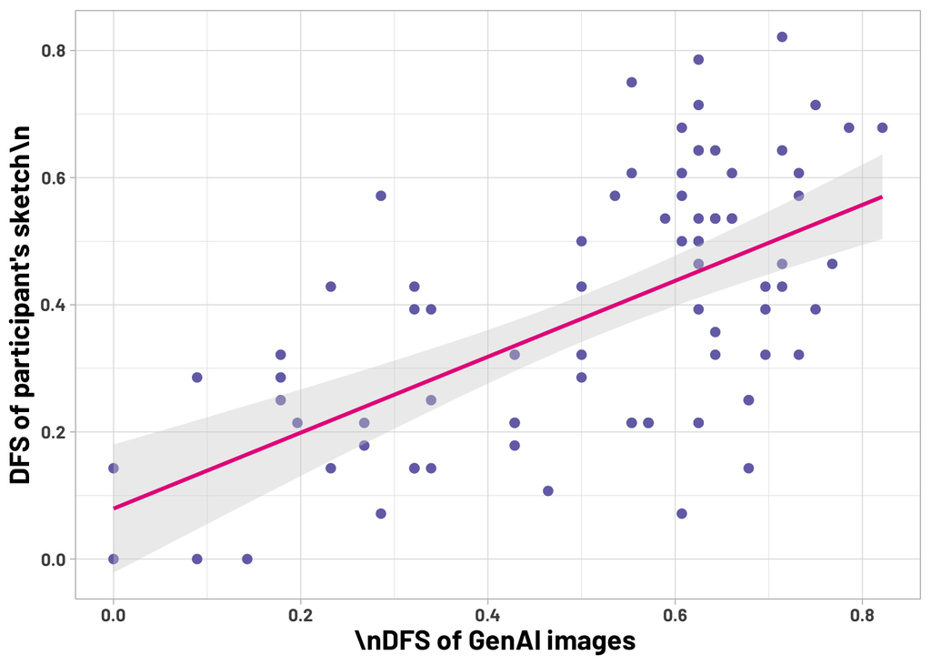

```r
ggplot(data, aes(x =similarity, y =dfs)) +
geom_point(color ="#7570B3", size = 2,) +
geom_smooth(method = lm, se = TRUE, fullrange = TRUE, color = "#E7298A", fill = "lightgrey") + # Change fill color
  labs(x = "\\nDFS of GenAI images ", y = "DFS of participant's sketch\\n") + # Change axis names
theme_light() +
theme(text = element_text(family = "Barlow", size = 12, face = "bold"), axis.title = element_text(size = 15, face = "bold")) +
scale_fill_brewer(palette = "PuBuGn", direction = +1) +
theme(legend.position = "none")
```

## 2.6 NASA-TLX

This section contains the NASA-TLX analysis.

### Data

```r
#Set working directory
setwd("~/Desktop/data") #Setup the working directory (where the data is)

#read data file
data <- read.csv("NASA_TLX.csv")
```

### Data summary

```r
# Calculate mean TLX scores

columns_to_analyze <- c("Mental_demand", "Physical_demand", "Temporal_demand", "Performance_demand", "Effort_demand", "Frustration_demand")  # Replace with your actual column names

all_results <- list()

# Loop over each column
for (column_name in columns_to_analyze) {
    # Calculate statistics for each condition and column
    no_support_stats <- data %>%
        filter(condition == "No support") %>%
        summarise(
            Condition = "No Support",
            Column = column_name,
            mean = mean(.data[[column_name]]),
            sd = sd(.data[[column_name]]),
            n = n(),
            sem = sd / sqrt(n)
        )%>%
        mutate(Combined = paste(round(mean, 2), " (", round(sem, 1), ")", sep = ""))

    gis_support_stats <- data %>%
        filter(condition == "GIS support") %>%
        summarise(
            Condition = "GIS Support",
            Column = column_name,
            mean = mean(.data[[column_name]]),
            sd = sd(.data[[column_name]]),
            n = n(),
            sem = sd / sqrt(n)
        )%>%
        mutate(Combined = paste(round(mean, 2), " (", round(sem, 1), ")", sep = ""))

    ai_support_stats <- data %>%
        filter(condition == "AI Support") %>%
        summarise(
            Condition = "AI Support",
            Column = column_name,
            mean = mean(.data[[column_name]]),
            sd = sd(.data[[column_name]]),
            n = n(),
            sem = sd / sqrt(n)
        )%>%
        mutate(Combined = paste(round(mean, 2), " (", round(sem, 1), ")", sep = ""))

    # Combine results for the current column
    combined_results_for_column <- bind_rows(no_support_stats, gis_support_stats, ai_support_stats)

    # Add a column for measure names
    combined_results_for_column$Measure <- column_name

    # Store the combined results in the list
    all_results[[column_name]] <- combined_results_for_column
}

# Combine all results into one table
final_combined_table <- do.call(rbind, all_results)

final_table <- final_combined_table %>%
  group_by(Measure) %>%
  summarise(
    `No Support` = paste(na.omit(Combined[Condition == "No Support"]), collapse = " "),
    `GIS Support` = paste(na.omit(Combined[Condition == "GIS Support"]), collapse = " "),
    `AI Support` = paste(na.omit(Combined[Condition == "AI Support"]), collapse = " ")
  )

final_table_ordered <- final_table %>%
  arrange(match(Measure, columns_to_analyze))

# Print the ordered final table
print(final_table_ordered)
```

```
## # A tibble: 6 × 4
##   Measure            `No Support` `GIS Support` `AI Support`
##   <chr>              <chr>        <chr>         <chr>
## 1 Mental_demand      4.05 (0.3)   4 (0.4)       4.2 (0.4)
## 2 Physical_demand    2.2 (0.3)    2.55 (0.3)    2.55 (0.3)
## 3 Temporal_demand    4.25 (0.4)   3.65 (0.4)    4.35 (0.4)
## 4 Performance_demand 4.1 (0.3)    5.15 (0.3)    4.65 (0.3)
## 5 Effort_demand      4.5 (0.3)    3.95 (0.4)    3.95 (0.2)
## 6 Frustration_demand 3.05 (0.4)   2 (0.3)       2.2 (0.3)
```

### Analysis

Anova for overall NASA TLX score

```r
data$NASA_TLX_Score <- sum(data$Mental_demand, data$Physical_demand, data$Temporal_demand, data$Performance_demand, data$Effort_demand, data$Frustration_demand)


NASA_TLX_anova <- aov(NASA_TLX_Score ~ condition, data = data)
summary(NASA_TLX_anova)
```

```
##             Df    Sum Sq   Mean Sq F value Pr(>F)
## condition    2 3.500e-25 1.748e-25       1  0.374
## Residuals   57 9.962e-24 1.748e-25
```

# References

Bürkner, Paul-Christian. 2017. “brms: An R Package for Bayesian Multilevel Models Using Stan.” *Journal of Statistical Software* 80 (1): 1–28. https://doi.org/10.18637/jss.v080.i01.

Carpenter, Bob, Andrew Gelman, Matthew D Hoffman, Daniel Lee, Ben Goodrich, Michael Betancourt, Marcus A Brubaker, Jiqiang Guo, Peter Li, and Allen Riddell. 2017. “Stan: A Probabilistic Programming Language.” *Journal of Statistical Software* 76.

Vehtari, Aki, Andrew Gelman, Daniel Simpson, Bob Carpenter, and Paul-Christian Bürkner. 2021. “Rank-Normalization, Folding, and Localization: An Improved $\widehat{R}$ for Assessing Convergence of MCMC (with Discussion).” *Bayesian Analysis* 16 (2): 667–718. https://doi.org/10.1214/20-BA1221.

Wickham, Hadley, Mara Averick, Jennifer Bryan, Winston Chang, Lucy D’Agostino McGowan, Romain François, Garrett Grolemund, et al. 2019. “Welcome to the Tidyverse.” *Journal of Open Source Software* 4 (43): 1686. https://doi.org/10.21105/joss.01686.

# Downloads

The data used for analysis and the .Rmd files can be downloaded here.

- Source

Data files:

- data_demographics_updated
- data_dfs
- data_variety
- data_originality
- NASA_TLX.csv

References:

- Reference list

# Session Information

```r
# sessionInfo()
```